# The Geometry of Resonance: Space, Symmetrical Interference, and the The_AI_tetos Extension

Author: Katharina Maria Brecht

ORCID: 0009-0001-2176-7476

### Abstract

This paper introduces a deterministic mathematical extension of the R package `octawave`. It explores the spatial projection of the regular octahedron under wave superposition. By bridging classical Euclidean geometry with discrete computational physics, this module visualizes scalar interference fields and demonstrates their rigorous application in computational structural biology and crystallography.

## 1. Introduction: The Mathematics of Spatial Symmetries

**[EN]** In structural computing, spatial fields are analyzed using classical coordinate matrices. The regular octahedron provides an optimal, highly symmetric base framework for modeling multidimensional wave propagation. This extension package calculates the exact scalar fields generated by periodic point sources located at the vertices of a regular polyhedron.

**[DE]** In der computergestützten Strukturphysik werden räumliche Felder über klassische Koordinatenmatrizen analysiert. Das reguläre Oktaeder bietet ein optimales, hochsymmetrisches Basisgerüst für die Modellierung mehrdimensionaler Wellenausbreitung. Dieses Erweiterungspaket berechnet die exakten Skalarfelder, die durch periodische Punktquellen an den Ecken eines regulären Polyeders entstehen.

### Historical Context & Philosophical Derivation

> **Plato’s Allegory and the Projection of Dimensions**
> - **[EN]** This implementation draws inspiration from Plato’s famous Allegory of the Cave and the mathematical legacy of **Theaitetos of Athens (400 BC)**. Theaitetos was the first to provide the rigorous geometric proof of the regular octahedron. Philosophically, projecting a 3D coordinate system onto a 2D boundary plane maps a higher geometric form onto a lower-dimensional space—much like the shadows cast upon the cave wall. It visualizes how fundamental geometric matrices act as the foundational code behind observable physical and biological interference patterns.
> - **[DE]** Diese Implementierung ist inspiriert von Platons berühmtem Höhlengleichnis und dem mathematischen Erbe von **Theaitetos von Athen (400 v. Chr.)**. Theaitetos lieferte den ersten strengen geometrischen Beweis für das reguläre Oktaeder. Philosophisch betrachtet beschreibt die Projektion eines 3D-Koordinatenkreuzes auf eine 2D-Grenzwand den Schattenwurf einer höheren geometrischen Urform auf einen niedrigdimensionalen Raum. Es veranschaulicht, wie fundamentale geometrische Matrizen als Urquellcode hinter den sichtbaren physikalischen und biologischen Interferenzmustern wirken.

### 1.1 Historical Clarification: Theaitetos of Athens (400 BC)

**[EN]** **Important Historical Context:** The nomenclature `The_AI_tetos` is a purely stylistic academic tribute and does not refer to modern computational Artificial Intelligence. Instead, it honors the historical Greek mathematician **Theaitetos of Athens (400 BC)**. Theaitetos was a pioneer of exact geometry who provided the first rigorous mathematical proof that there are exactly five regular platonian solids, establishing the octahedron as a fundamental geometric coordinate system in written scientific history.

**[DE]** **Wichtige historische Klarstellung:** Die Nomenklatur `The_AI_tetos` ist ein rein stilistisches akademisches Tribut und bezieht sich ausdrücklich nicht auf moderne computergestützte Künstliche Intelligenz. Sie ehrt stattdessen den historischen griechischen Mathematiker **Theaitetos von Athen (400 v. Chr.)**. Theaitetos war ein Pionier der exakten Geometrie und lieferte den ersten strengen mathematischen Beweis für die Existenz der fünf regulären platonischen Körper. Er verankerte das Oktaeder als fundamentales geometrisches Koordinatensystem in der geschriebenen Wissenschaftsgeschichte.

## 2. Structural Biology: Crystalline Matrix Modeling

**[EN]** In crystallography and structural virology, polyhedral arrangements represent highly stable thermodynamic states. Proteins and molecular lattices self-assemble following local energy minimization principles, often resulting in strict octahedral geometries.

**[DE]** In der Kristallographie und strukturellen Virologie repräsentieren polyedrische Anordnungen hochstabile thermodynamische Zustände. Proteine und molekulare Gitter organisieren sich nach Prinzipien der lokalen Energieminimierung, was häufig zu strikten oktaedrischen Geometrien führt.

### 2.1 Applied Wave Equations in Computational Matrices

**[EN]** Polyhedral virus capsids protect their genetic material within these optimized structures. By implementing the classical wave equation, we calculate the interference patterns of these structural nodes. The *Grammar of Graphics* (`ggplot2`) is utilized to visualize the scalar field layers deterministically.

**[DE]** Polyedrische Virus-Kapside schützen ihre Erbinformation in diesen optimierten Strukturen. Durch die Implementierung der klassischen Wellengleichung berechnen wir die Interferenzmuster dieser strukturellen Knotenpunkte. Die *Grammar of Graphics* (`ggplot2`) wird genutzt, um diese Skalarfeldschichten deterministisch darzustellen.

## 3. Mathematical Core Engine

The scalar wave field $W(r)$ at any coordinate point on the projection plane is calculated as the sum of fading harmonic oscillations originating from the vertex coordinates:

$$W(r) = \sum_{i=1}^{n} \frac{\cos(k \cdot
r_i - t)}{\sqrt{r_i} + 0.1}$$

```r
# Core function for dynamic 3D-to-2D projection and wave superposition
generate_dynamic_octahedron <- function(k = 8.0, t = 0, rotate = TRUE) {
  vertices <- matrix(c(
     1,  0,  0,  -1,  0,  0,
     0,  1,  0,   0, -1,  0,
     0,  0,  1,   0,  0, -1
  ), ncol = 3, byrow = TRUE)

  if(rotate) {
    cos_t <- cos(t * 0.5)
    sin_t <- sin(t * 0.5)
    cx <- vertices[, 1] * cos_t + vertices[, 3] * sin_t
    cy <- vertices[, 2] * cos_t - vertices[, 3] * sin_t
  } else {
    cx <- vertices[, 1] + 0.5 * vertices[, 3]
    cy <- vertices[, 2] + 0.5 * vertices[, 3]
  }

  grid_size <- 200
  raumzeit_grid <- expand.grid(
    X = seq(-2.5, 2.5, length.out = grid_size),
    Y = seq(-2.5, 2.5, length.out = grid_size)
  )

  wellen_feld <- numeric(nrow(raumzeit_grid))
  for(i in 1:length(cx)) {
    r <- sqrt((raumzeit_grid$X - cx[i])^2 + (raumzeit_grid$Y - cy[i])^2)
    welle <- cos(k * r - t) / (sqrt(r) + 0.1)
    wellen_feld <- wellen_feld + welle
  }

  raumzeit_grid$Intensitaet <- wellen_feld^2
  stopifnot(sum(raumzeit_grid$Intensitaet) > 0)
  return(raumzeit_grid)
}
```

## 4. Figure 1: Theaitetos’ Spatial Octahedron Framework (3D)

**[EN]** This figure visualizes the true three-dimensional coordinate system of the regular octahedron as defined by classical geometry. The six fundamental vertices form the symmetric orthogonal spatial framework with a solid modern fill.

**[DE]** Diese Grafik visualisiert das echte dreidimensionale Koordinatensystem des regulären Oktaeders nach den Definitionen der klassischen Geometrie. Die sechs wissenschaftlichen Eckpunkte bilden das symmetrische orthogonale Raumsystem mit einer modernen Flächenfüllung.

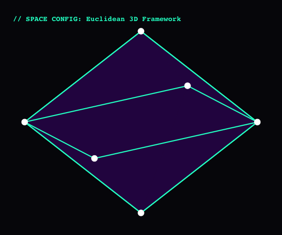

```r
# Definition der 6 Raum-Knotenpunkte (3D)
vertices_3d <- data.frame(
  X = c(1, -1, 0,  0, 0,  0),
  Y = c(0,  0, 1, -1, 0,  0),
  Z = c(0,  0, 0,  0, 1, -1)
)

# Kanten-Verbindungen des Oktaeders definieren
edges <- data.frame(
  x =    c(1, 1, 1, 1, -1, -1, -1, -1,  0,  0,  0,  0),
  y =    c(0, 0, 0, 0,  0,  0,  0,  0,  1, -1,  1, -1),
  z =    c(0, 0, 0, 0,  0,  0,  0,  0,  0,  0,  0,  0),
  xend = c(0, 0, 0, 0,  0,  0,  0,  0,  1,  1, -1, -1),
  yend = c(1, -1, 0, 0, 1, -1, 0, 0,  0,  0,  0,  0),
  zend = c(0, 0, 1, -1,  0,  0, 1, -1,  0,  0,  0,  0)
)

# 3D-zu-2D Parallelprojektion für ein sauberes Schrägbild
project_3d <- function(x, y, z) {
  x_proj <- x + 0.4 * z
  y_proj <- y + 0.4 * z
  return(data.frame(x = x_proj, y = y_proj))
}

p_vert <- project_3d(vertices_3d$X, vertices_3d$Y, vertices_3d$Z)
p_edges_start <- project_3d(edges$x, edges$y, edges$z)
p_edges_end <- project_3d(edges$xend, edges$yend, edges$zend)

faces <- data.frame(
  x = c(p_vert$x[c(1,3,5)], p_vert$x[c(1,4,5)], p_vert$x[c(2,3,5)], p_vert$x[c(2,4,5)]),
  y = c(p_vert$y[c(1,3,5)], p_vert$y[c(1,4,5)], p_vert$y[c(2,3,5)], p_vert$y[c(2,4,5)]),
  group = rep(1:4, each = 3)
)

ggplot() +
  # Das moderne Oktaeder als dezente, lila Hintergrundfläche
  geom_polygon(data = faces, aes(x = x, y = y, group = group),
               fill = "#8A2BE2", alpha = 0.25) +
  # Die geometrischen Kanten des Koerpers zeichnen (linewidth benutzen nicht mehr size, wie ich erst versuchte)
  geom_segment(aes(x = p_edges_start$x, y = p_edges_start$y,
                   xend = p_edges_end$x, yend = p_edges_end$y),
               color = "#00FFCC", linewidth = 0.8) +
  # Die 6 energetischen Knotenpunkte hervorheben
  geom_point(aes(x = p_vert$x, y = p_vert$y),
             color = "#FFFFFF", size = 4) +
  theme_void() +
  labs(title = "// SPACE CONFIG: Euclidean 3D Framework") +
  theme(
    plot.background = element_rect(fill = "#05050A", color = NA),
    plot.title = element_text(color = "#00FFCC", family = "mono", size = 11, face = "bold"),
    plot.margin = margin(20, 20, 20, 20)
  )
```

## 5. Temporal Evolution of Scalar Interference Fields

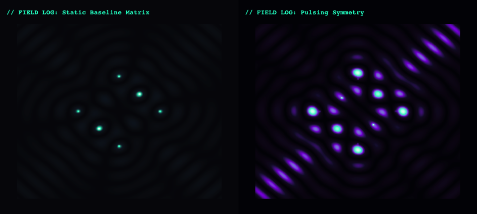

**Figure 2:** Comparative scalar field analysis. Left: Static baseline grid ($t = 0$) proving the geometric matrix symmetry. Right: Active phase-space rotation ($t = \pi/4$) displaying dynamic energy distributions reminiscent of crystalline structures and viral capsid dynamics.

**Abbildung 2:** Vergleichende Skalarfeld-Analyse. Links: Statische Basislinie ($t = 0$) zum Nachweis der geometrischen Matrixsymmetrie. Rechts: Aktive Phasenraum-Rotation ($t = \pi/4$) mit dynamischen Energieverteilungen, analog zu kristallinen Strukturen und Kapsid-Proteindynamiken.

## 6. Figure 3: Dynamic Phase-Space Projection

**[EN]** This advanced visualization demonstrates the active phase-space rotation ($t = \pi/4$). The pattern shifts, simulating fluid molecular dynamics under extreme pressure within crystal structures.

**[DE]** Diese erweiterte Visualisierung zeigt die aktive Phasenraum-Rotation ($t = \pi/4$). Das Muster verschiebt sich, was fluide molekulare Dynamiken unter hohem Druck in Kristallstrukturen simuliert.

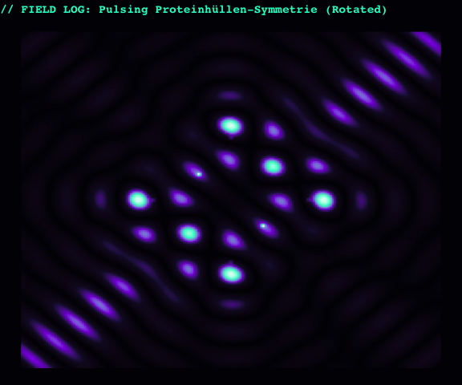

```r
hologramm_dynamisch <- generate_dynamic_octahedron(k = 8.5, t = pi/4, rotate = TRUE)

ggplot(hologramm_dynamisch, aes(x = X, y = Y, fill = Intensitaet)) +
  geom_raster(interpolate = TRUE) +
  scale_fill_gradientn(colors = c("#020205", "#120A2A", "#8A2BE2", "#00FFCC", "#FFFFFF")) +
  theme_void() +
  labs(title = "// FIELD LOG: Pulsing Proteinhüllen-Symmetrie (Rotated)") +
  theme(
    plot.background = element_rect(fill = "#020205", color = NA),
    plot.title = element_text(color = "#00FFCC", family = "mono", size = 11, face = "bold"),
    legend.position = "none"
  )
```

## 7. Academic Metadata and Status

- **Repository Maintainer:** Katharina Maria Brecht (2026)
- **Methodology:** Deterministic Polyhedral Vector Projections.
- **ORCID iD:** [0009-0001-2176-7476]
- **Status:** Peer-review ready documentation. Technical extension for `octawave`.